# Introduction to R (in 3 hours or less)

## Matricies and Arrays

You can also store numbers in two dimensional arrays (matrices). This can make your code very efficient if it can be represented as a series of matrix operations.

```r
A <- matrix(1:9, nrow = 3)
A
```

```
     [,1] [,2] [,3]
[1,]    1    4    7
[2,]    2    5    8
[3,]    3    6    9
```

**TipTest your understanding**

Make a 3 by 2 matrix $B$ containing the numbers 1 to 6.

```r
# your code goes here
B <- matrix(1:6, nrow = 3)
B
```

```
     [,1] [,2]
[1,]    1    4
[2,]    2    5
[3,]    3    6
```

**TipTest your understanding**

Use `%*%` to calculate $AB$.

```r
# your code goes here
A%*%B
```

```
     [,1] [,2]
[1,]   30   66
[2,]   36   81
[3,]   42   96
```

**TipTest your understanding**

Create a matrix $C$ as defined below and calculate its inverse using `solve()`. Store $C^{-1}$ assign the result to `C_inv`

$$C = \begin{bmatrix}
1 & 1 & 0 \\
0 & 1 & 1 \\
0 & 0 & 1
\end{bmatrix}.
\tag{1}$$

```r
#your code goes here
C <- matrix(c(1, 1, 0,
              0, 1, 1,
              0, 0, 1),
            nrow = 3, byrow = TRUE)
C
```

```
     [,1] [,2] [,3]
[1,]    1    1    0
[2,]    0    1    1
[3,]    0    0    1
```

```r
C_inv <- solve(C)
C_inv
```

```
     [,1] [,2] [,3]
[1,]    1   -1    1
[2,]    0    1   -1
[3,]    0    0    1
```

You will often want to calculate row-wise or column-wise summary statistics of matrices and other grid-like data structures.

Some summary statistics have nice built-in functions such as `rowSums()` and `colSums()`. For less common summaries we can use the `apply()` function to *apply* another function to each row of column of a matrix.

```r
rowSums(A)
```

```
[1] 12 15 18
```

```r
apply(X = A, MARGIN = 1, FUN = sum)
```

```
[1] 12 15 18
```

```r
colMeans(A)
```

```
[1] 2 5 8
```

```r
apply(X = A, MARGIN = 2, FUN = mean)
```

```
[1] 2 5 8
```

This is the first time we have seen a function with multiple inputs (arguments). These can be given without names in the default order or in any order with names.

**TipTest your understanding**

Calculate the column means of $C$ and the row medians of $C^{-1}$.

```r
# Your code goes here
```

**Tip**

In RStudio you can preview the inputs of a function by typing its name with an open parenthesis and then pressing tab. (e.g. `apply(` + `tab`.)

You can then use the arrow keys to move through the inputs.

To get more detailed information on a function you can look at its documentation.

To show the documentation for a function, put a question mark before its name. `?apply`

**TipTest your understanding**

- What is the second argument of `max()` and what does it do?
- Look at the documentation for `rowSums()`. What subtle difference is there between `rowSums(A)` and `apply(X = A, MARGIN = 1, FUN = sum)`?

## Data Frames

So far we have focused on collecting together data that is all of the same type. A `data.frame` allows you to gather data of different types.

Usually each row will represent one observational unit (a person, a penguin, a city) and each column represents a measured quantity (age, gender, sex, species, population, capital status).

```r
grades <- data.frame(student_id = 1:3, score = c(90, 85, 88))
grades
```

```
  student_id score
1          1    90
2          2    85
3          3    88
```

```r
# Avoid very long lines by using line breaks
grades <- data.frame(
  student_id = 1:6,
  score = c(90, 85, 88, 52, 66, 41),
  class = c("Distinction", "Distinction", "Distinction", "Pass", "Merit", "Fail"),
  pass = c(rep(TRUE, 5), FALSE)
)

grades
```

```
  student_id score       class  pass
1          1    90 Distinction  TRUE
2          2    85 Distinction  TRUE
3          3    88 Distinction  TRUE
4          4    52        Pass  TRUE
5          5    66       Merit  TRUE
6          6    41        Fail FALSE
```

We can extract individual rows using their row and column indices

```r
# first row
grades[1, ]
```

```
  student_id score       class pass
1          1    90 Distinction TRUE
```

```r
# second column
grades[ ,2]
```

```
[1] 90 85 88 52 66 41
```

```r
# first row of second column
grades[1, 2]
```

```
[1] 90
```

Or using the column names:

```r
grades$class
```

```
[1] "Distinction" "Distinction" "Distinction" "Pass"        "Merit"
[6] "Fail"
```

```r
grades[ ,"class"]
```

```
[1] "Distinction" "Distinction" "Distinction" "Pass"        "Merit"
[6] "Fail"
```

```r
grades[, c("score", "class")]
```

```
  score       class
1    90 Distinction
2    85 Distinction
3    88 Distinction
4    52        Pass
5    66       Merit
6    41        Fail
```

Or using logical conditions:

```r
grades[grades$pass == FALSE, ]
```

```
  student_id score class  pass
6          6    41  Fail FALSE
```

**TipTest your understanding**

Subset the `grades` data frame to extract the id and score of the students whose grade is at least 87.

```r
# your code goes here
```

**TipTest your understanding**

Is there any difference between `grades$class` and `grades[ ,"class"]`?

```r
# your code goes here
```

You can add elements to a data.frame by assigning them to non-existent columns or rows. (Be careful of the latter!)

```r
grades$gender <- rep("Female", 6)
```

**TipTest your understanding**

Make up a vector with an additional entry and try adding it as a 7th row of `grades`. What happens? Why do you think that happens?

## Lists

Lists generalise data.frames by allowing us to have entries of different data types *and* different lengths.

```r
zv <- list(
  forename = "Zak",
  surname = "Varty",
  years_at_imperial = 4,
  modules = c('Data Science', "Ethical MLDS"))
```

You can even get wild and have nested lists, where elements of the list are themselves lists!

```r
zv <- list(
  forename = "Zak",
  surname = "Varty",
  years_at_imperial = 4,
  modules = list(
    data_science = list(programme = "MSc Stats",
                        students = 85,
                        online = FALSE,
                        room = "HXLY 139"),
    ethical_mlds = list(programme = "MSc MLDS",
                        students = 95,
                        online = TRUE))
  )

zv$modules
```

```
$data_science
$data_science$programme
[1] "MSc Stats"

$data_science$students
[1] 85

$data_science$online
[1] FALSE

$data_science$room
[1] "HXLY 139"


$ethical_mlds
$ethical_mlds$programme
[1] "MSc MLDS"

$ethical_mlds$students
[1] 95

$ethical_mlds$online
[1] TRUE
```

R also has some other, application specific, data structures but under the hood these are usually just lists.

## Reading and Writing Data

If we have tabular data, a comma separated value (csv) file is one of the most accessible ways to store it. We can create files using `write.csv()`

```r
write.csv(grades, "grades.csv")
```

We can then remove it from our workspace

```r
rm(grades)
```

and re-load it from the CSV we just created

```r
grades <- read.csv("grades.csv")
```

If we want to save R objects in their existing form we can use an R Data Serialised (RDS) file. This lets us save and load more complicated data structures but at the expense of these being less accessible.

(RDS files are not human-readable and are not easily ported between programming languages.)

**TipTest your understanding**

Follow the previous example to use `saveRDS()` and `readRDS()` to save the `zv` nested list to a file, remove it from the workspace and reload it from the file you just created.

```r
# your code goes here
```

**Warning**

> It is important to be aware of where in your file system R is running. This is the so-called “working directory” and file paths are relative to this location. Use `pwd` in the terminal or `getwd()` in R to find this out.

> If your code is run from a notebook document like Rmd, qmd and jupytper notebook code and any file paths will be run from the location of the notebook.

> If you are editing a notebook in RStudio, the working directory for your console might not be the same as the location of the notebook. While you can use `setwd()` to change this, it is much better to design your projects to use [portable file paths](https://eds-notes.zakvarty.com/103-workflows-organising-your-code#structuring-r-script-headers). The `{here}` package can be helpful for this, check out the [getting started](https://here.r-lib.org/articles/here.html) documentation.

# 2. R as a statistical programming language

## Referencing statistical distributions

### Probability Density / Mass Functions

Probability density/mass functions can be referenced using functions with a `d` prefix. (e.g. `dnorm()`, `dgamma()`, …)

```r
dnorm(x = 0, mean = 0, sd = 1)
```

```
[1] 0.3989423
```

```r
# sanity check (our first unit test!)
1/(sqrt(2 * pi))
```

```
[1] 0.3989423
```

We can pass vectors as inputs. Smaller inputs will be “recycled”

```r
dnorm(x = 1:6, mean = 1:3, sd = 1:2)
```

```
[1] 0.398942280 0.199471140 0.398942280 0.064758798 0.004431848 0.064758798
```

```r
#lecture code (same result as above)
dnorm(x = 1:6, mean = rep(1:3, 2), sd = rep(1:2, 3))
```

```
[1] 0.398942280 0.199471140 0.398942280 0.064758798 0.004431848 0.064758798
```

**TipTest your understanding**

Describe to your neighbour which probability density functions are being referenced in the above code.

This same feature allows us to easily plot probability density functions.

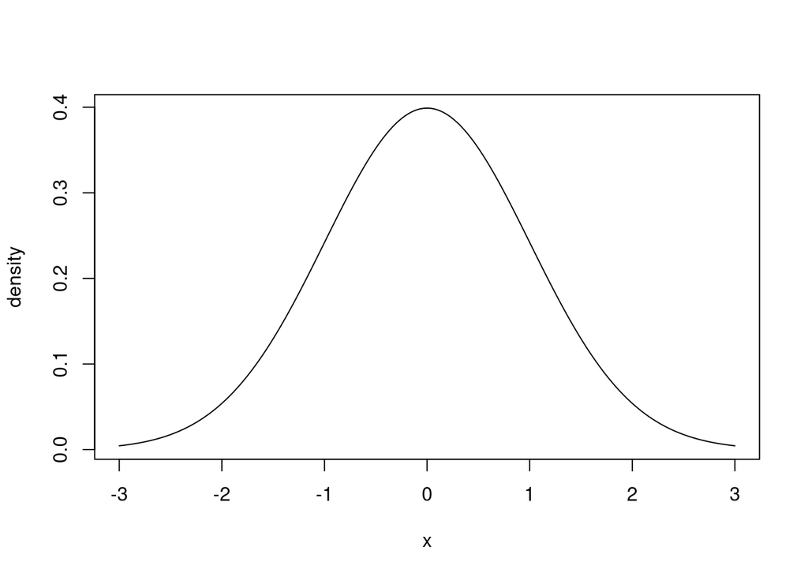

```r
x <- seq(from = -3,to = 3, by = 0.01)
density <- dnorm(x = x, mean = 0 , sd = 1)

plot(x = x, y = density, type = "l")
```

### Probability functions

Probability functions take as input a value and return the corresponding quantile level of the distribution ($x \rightarrow \Pr(X \leq x)$).

```r
# check against some reference values
pnorm(q = -1.64, mean = 0, sd = 1)
```

```
[1] 0.05050258
```

```r
pnorm(q = 0, mean = 0, sd = 1)
```

```
[1] 0.5
```

```r
pnorm(q = 1.96, mean = 0, sd = 1)
```

```
[1] 0.9750021
```

These functions can be used to easily plot cumulative distribution functions

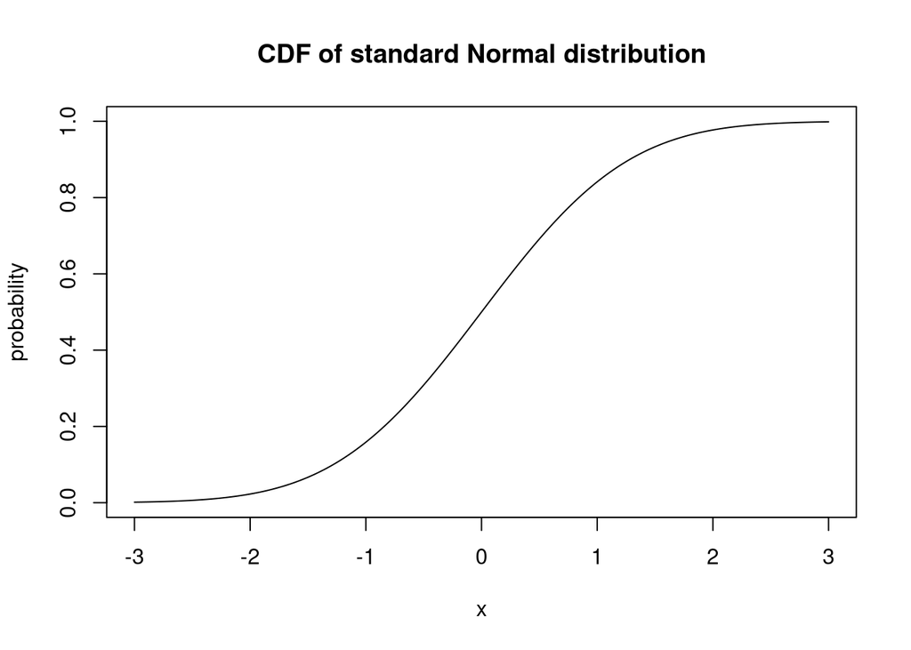

```r
x <- seq(from = -3,to = 3, by = 0.01)
probability <- pnorm(q = x, mean = 0 , sd = 1)

plot(x = x,
     y = probability,
     type = "l",
     main = "CDF of standard Normal distribution")
```

Finally, quantile functions take a probability and return the corresponding quantile of that distribution.

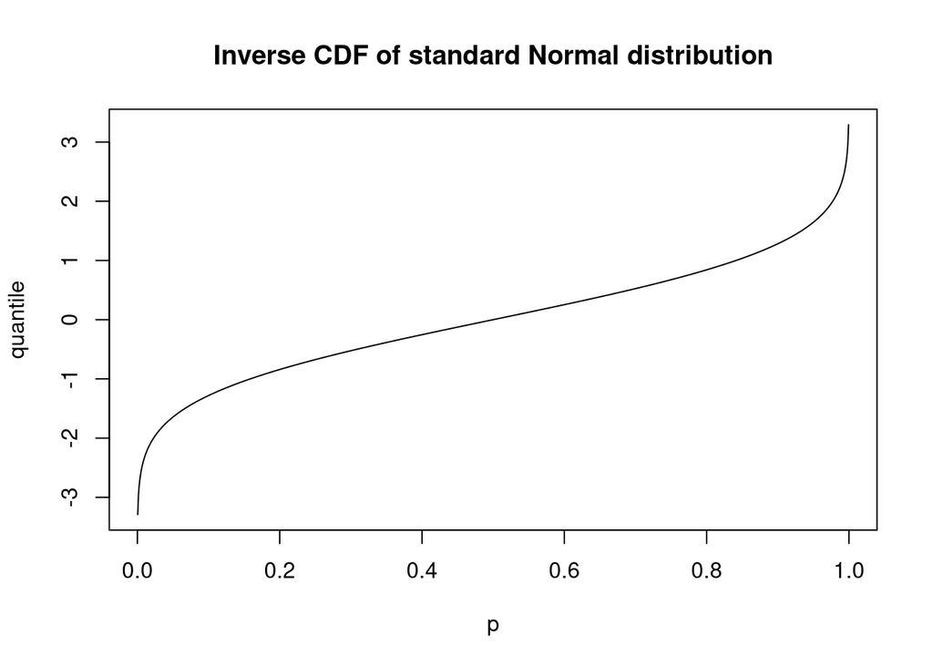

```r
p <- ppoints(1001)
quantile <- qnorm(p = p, mean = 0, sd = 1)

plot(
  x = p,
  y = quantile,
  type = "l",
  main = "Inverse CDF of standard Normal distribution")
```

**TipTest your understanding**

Make similar plots for the standard exponential distribution.

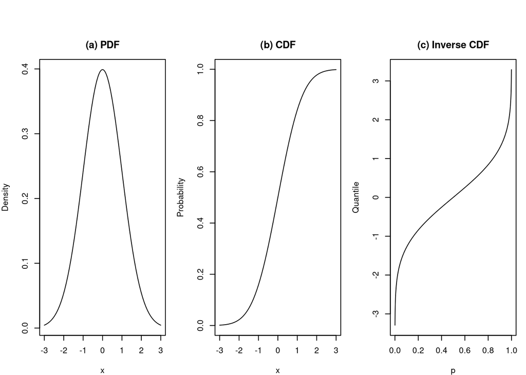

```r
# your code goes here
# Data
x <- seq(from = -3, to = 3, by = 0.01)
density <- dnorm(x = x, mean = 0, sd = 1)
probability <- pnorm(q = x, mean = 0, sd = 1)

p <- ppoints(1001)
quantiles <- qnorm(p = p, mean = 0, sd = 1)

# Layout: 1 row, 3 columns
par(mfrow = c(1, 3),      # 1x3 layout
    mar = c(4, 4, 3, 1),  # margins for each plot
    oma = c(0, 0, 3, 0))  # outer margin for caption

# (a)
plot(x = x,
     y = density,
     type = "l",
     main = "(a) PDF",
     xlab = "x",
     ylab = "Density")

# (b)
plot(x = x,
     y = probability,
     type = "l",
     main = "(b) CDF",
     xlab = "x",
     ylab = "Probability")

# (c)
plot(x = p,
     y = quantiles,
     type = "l",
     main = "(c) Inverse CDF",
     xlab = "p",
     ylab = "Quantile")

# Caption
mtext("Figure: PDF, CDF, and inverse CDF of the standard normal distribution.",
      side = 1, outer = TRUE, line = 1, cex = 1)
```

```r
# Optional: reset plotting layout
par(mfrow = c(1, 1))
```

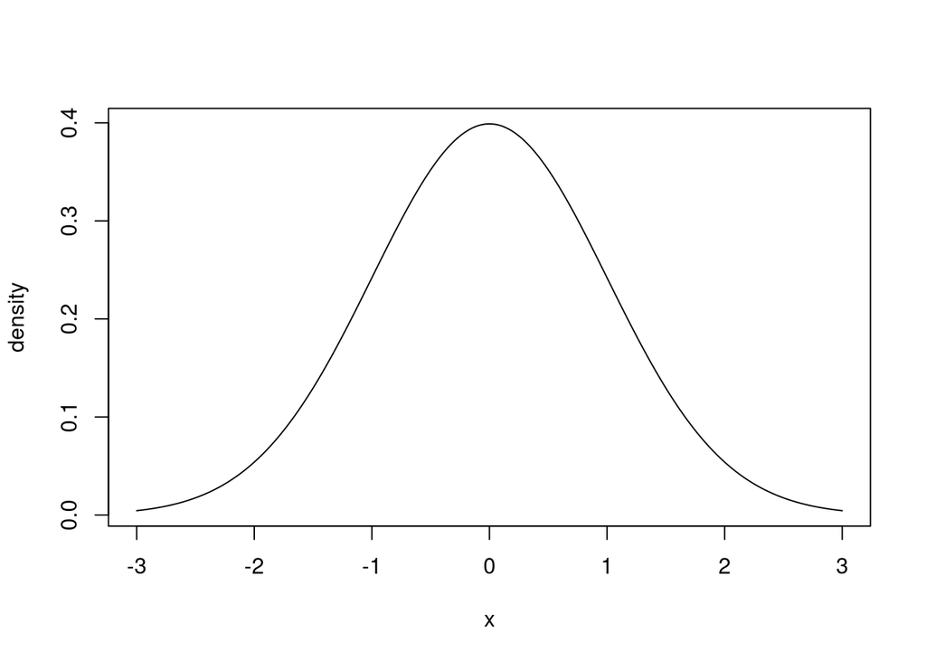

(a) Probability density function

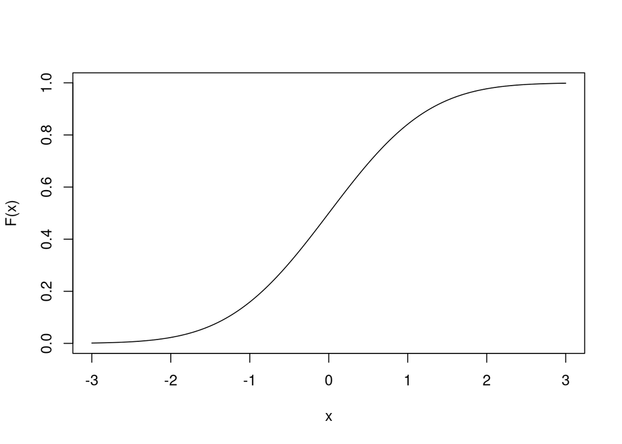

(b) Cumulative distribution function

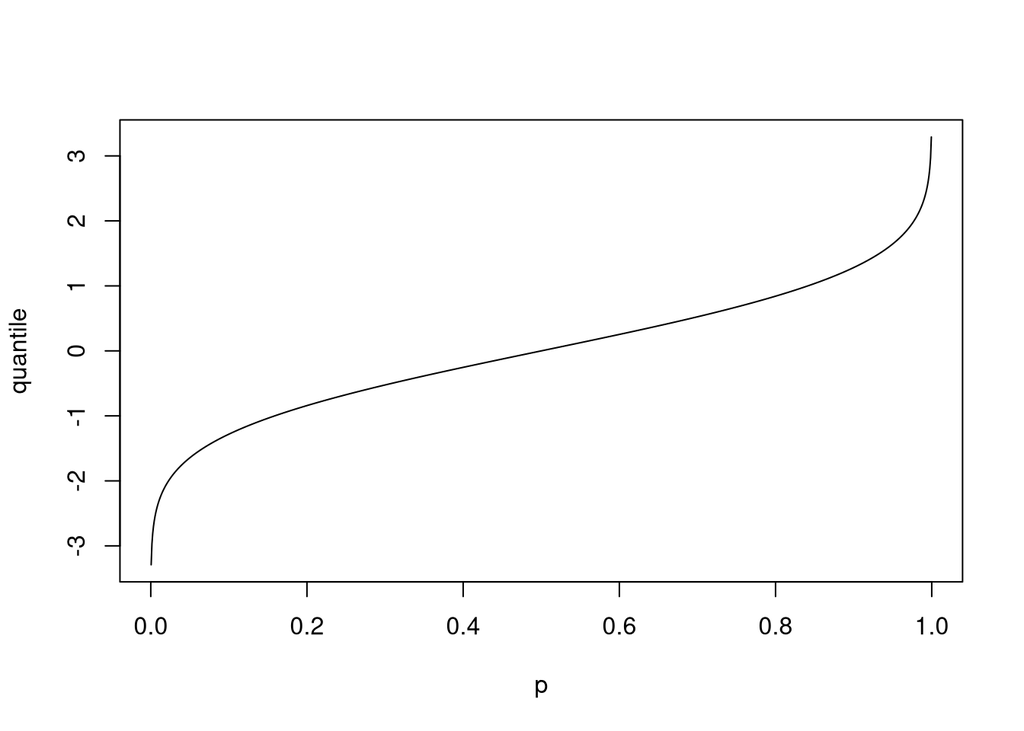

(c) Quantile or inverse cumulative distribution function

```r
x <- seq(from = -3, to = 3, by = 0.01)
density <- dnorm(x = x, mean = 0, sd = 1)
probability <- pnorm(q = x, mean = 0, sd = 1)

p <- ppoints(1001)
quantiles <- qnorm(p = p, mean = 0, sd = 1)

plot(x, density,
     type = "l",
     xlab = "x",
     ylab = "density")

plot(x, probability,
     type = "l",
     xlab = "x",
     ylab = "F(x)")

plot(p, quantiles,
     type = "l",
     xlab = "p",
     ylab = "quantile")
```

The standard normal distribution.

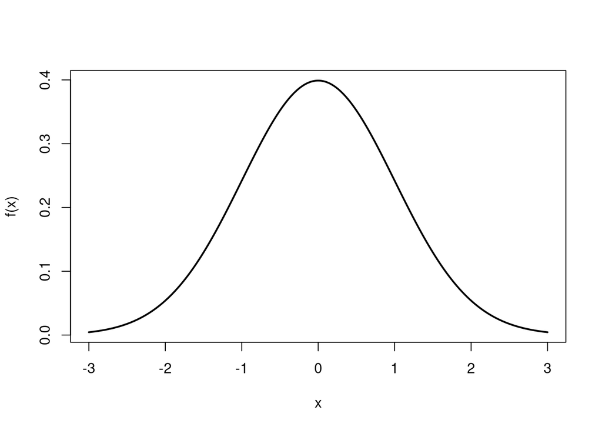

(a) Probability density function

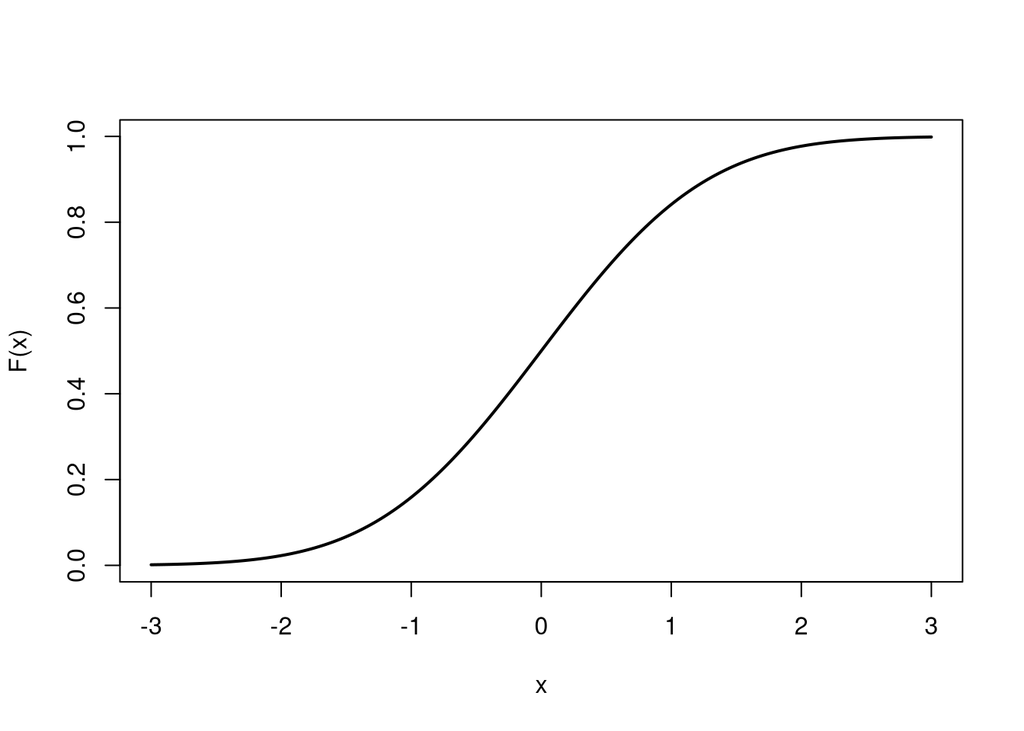

(b) Cumulative distribution function

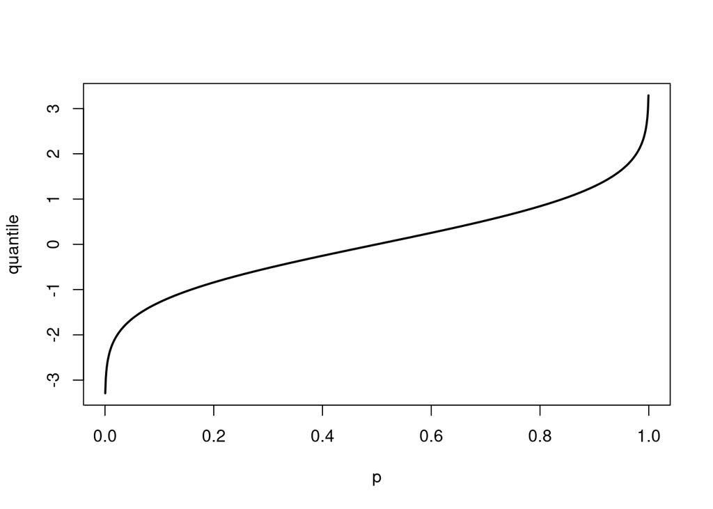

(c) Quantile or inverse cumulative distribution function

```r
x <- seq(-3, 3, by = 0.01)
density <- dnorm(x, mean = 0, sd = 1)
probability <- pnorm(x, mean = 0, sd = 1)

p <- ppoints(1001)
quantiles <- qnorm(p, mean = 0, sd = 1)

plot(x, density, type = "l", xlab = "x", ylab = "f(x)", lwd = 2)
plot(x, probability, type = "l", xlab = "x", ylab = "F(x)", lwd = 2)
plot(p, quantiles, type = "l", xlab = "p", ylab = "quantile", lwd = 2)
```

The standard normal distribution.

**TipTest your understanding**

- What do you think are the names of the equivalent functions for the continuous uniform distribution?
- Why might one of these names be confusing?

## Simulating from statistical distributions

We can simulate a realisation of a random variable by using the equivalent functions with an “r” prefix. We could generate a single random variate from the standard normal distribution.

```r
rnorm(n = 1, mean = 0, sd = 1)
```

```
[1] -1.390172
```

To simulate lots of random variates we increase the sample size, `n`.

```r
rnorm(n = 5, mean = 1, sd = 1)
```

```
[1]  0.6039157 -0.9263810  0.9641692  1.3751689  1.7358213
```

Similar to previous functions we can vectorise the inputs.

```r
rnorm(n = 5, mean = 1:5, sd = 1)
```

```
[1] 2.363212 2.817308 0.661828 2.122008 5.363248
```

But if we re-run the same line of code we get a different set of outputs.

```r
rnorm(n = 5, mean = 1:5, sd = 1)
```

```
[1] 0.5853528 2.2183980 2.5537455 4.3760113 3.8906377
```

This is exactly what we want but is terrible for reproducibility. What if your work is reviewed and the conclusions no longer match the simulated data?

We can set the *seed* of our random number generator to avoid this problem. Suppose in our simulations we want to generate two sets of random numbers.

```r
set.seed(1234)
rnorm(n = 5, mean = 1:5, sd = 1)
```

```
[1] -0.2070657  2.2774292  4.0844412  1.6543023  5.4291247
```

```r
rnorm(n = 5, mean = 1:5, sd = 1)
```

```
[1] 1.506056 1.425260 2.453368 3.435548 4.109962
```

We get different numbers each time we run `rnorm()` but if we rerun the entire code we will get the same result.

```r
set.seed(1234)
rnorm(n = 5, mean = 1:5, sd = 1)
```

```
[1] -0.2070657  2.2774292  4.0844412  1.6543023  5.4291247
```

```r
rnorm(n = 5, mean = 1:5, sd = 1)
```

```
[1] 1.506056 1.425260 2.453368 3.435548 4.109962
```

You can think of the seed as the starting point in a long list of random numbers and you are choosing which entry to start reading from.

> **Reproducibile Results:** Do you get the exact same results each time code is run?

Benefits of reproducible results:

- *Debugging your code* is much easier
- *Testing your code* is much easier
- *Comparing methods* is more robust
- *Convincing others* is much simpler.

**WarningWe are data scientists, not cherry pickers!**

One caveat is to be wary of “seed hacking”. While checking that your results stay the same numerically for a given seed, the qualitative conclusions you draw should be stable across a range of seed values.

**TipTest your understanding**

1. Without setting a seed, simulate 2 datasets. Each should be a different size and be drawn from two Normal distributions with different parameters.
2. Use `qqnorm()` to create a plot comparing the quantiles of your samples to the quantiles of the best-fitting Normal distribution.
3. Rerun your previous code and see the plots change.
4. Add a seed to your code and check that you get the same plots every time.
5. Use `hist()` to create a histogram for each of your samples.

```r
# your code goes here
```

# 3. Don’t Repeat Yourself!

## DRY - For Loops

Sometimes you have to do things over and over and over and over and over….

If there is structure to what you are doing, you don’t need to repeat yourself in code.

```r
# The dumb way
print("a")
```

```
[1] "a"
```

```r
print("b")
```

```
[1] "b"
```

```r
print("c")
```

```
[1] "c"
```

```r
print('...')
```

```
[1] "..."
```

```r
# The DRY way
for (i in 1:26){
  print(letters[i])
}
```

```
[1] "a"
[1] "b"
[1] "c"
[1] "d"
[1] "e"
[1] "f"
[1] "g"
[1] "h"
[1] "i"
[1] "j"
[1] "k"
[1] "l"
[1] "m"
[1] "n"
[1] "o"
[1] "p"
[1] "q"
[1] "r"
[1] "s"
[1] "t"
[1] "u"
[1] "v"
[1] "w"
[1] "x"
[1] "y"
[1] "z"
```

Here `i` is a *dummy variable*. It exists only within that for look and progresses through the values of `c(1, 2, ..., 26)` as the code in curly brackets gets executed for each of these values.

Since `i` is a dummy variable, we can call it anything we like. A more informative way of writing the same code would be:

```r
for (letter in letters) {
  print(letter)
}
```

```
[1] "a"
[1] "b"
[1] "c"
[1] "d"
[1] "e"
[1] "f"
[1] "g"
[1] "h"
[1] "i"
[1] "j"
[1] "k"
[1] "l"
[1] "m"
[1] "n"
[1] "o"
[1] "p"
[1] "q"
[1] "r"
[1] "s"
[1] "t"
[1] "u"
[1] "v"
[1] "w"
[1] "x"
[1] "y"
[1] "z"
```

> **Note:** For loops are relatively slow compared to vectorisation. They should mainly be used when there is a requirement for things to be done sequentially.

**TipTest your understanding**

Write a loop that prints whether each number from 1 to 5 is even or odd.

```r
# your code goes here
```

**TipTest your understanding**

A useful helper functions to use with for loops is `seq_along()`. What do you think it does?

## DRY - While Loops

One downside to `for` loops is that, before you run the code, you either need an object to iterate along or to know how many times to repeat the code within the curly braces.

`while`-loops avoid this need. They will repeat the bracketed code until the condition you pre-specify is no longer `TRUE`.

```r
j <- 12
i <- 0

while (j > 0.002) {
  j <- j / 3
  i <- i + 1
  print(j)
}
```

```
[1] 4
[1] 1.333333
[1] 0.4444444
[1] 0.1481481
[1] 0.04938272
[1] 0.01646091
[1] 0.005486968
[1] 0.001828989
```

You can use any sort of Boolean condition as your condition:

- Comparisons: `<`, `<=`, `==`, `>=`, `>`, `!==`.
- Functions which evaluate to `TRUE` or `FALSE`: `%in%` ,`is.na()`

**Warning**

There is danger here. If the condition is always `TRUE` you will be stuck in an infinite loop and your code will never stop running. (Note: this is not as scary as it sounds!)

```r
j <- 12
i <- 0

while (j > 0.002) {
  i <- i / 3
  j <- j + 1
  Sys.sleep(1)         # slow things down
  print(j)
}
```

## DRY - Control Flow

While loops lead us nicely into flow control. This is where under different conditions you want to take different actions. `if` and `else` allow you to do this and take the same structure as `while`.

```r
a <- 1
if (a > 2) {print(a)}
if (a > 0) {print("a is positive")}
if (a == 0) {print("a is neither postive nor negative")}
if (a < 0) {print("a is negative")}
```

```r
a <- 1
if (a > 2) {
  print(a)
} else if (a > 0) {
  print("a is positive")
} else if (a < 0) {
  print("a is negative")
} else {
  print("a is neither positive nor negative")
}
```

Multiple-case flow control like this can be hard to read and write but they do have a computational benefit if one of the `if` conditions is expensive to evaluate and sometimes having a catch-all `else` term is useful for handling unexpected situations gracefully.

**TipTest your understanding**

Can you think of an example where the second code would work but the first would not?

**TipTest your understanding**

Write a loop that prints whether each number from 1 to 5 is even or odd. You might find `%%` useful for this.

```r
# your code goes here
```

**TipTest your understanding**

Write code that picks a number $N$ between 5 and 10 (inclusive) uniformly at random. Write a loop that prints whether each number from n to 10 is even or odd.

```r
# your code goes here
```

**TipTest your understanding**

Write code that starts with an empty vector `c()` and simulates exponential random variates until their sum exceeds 10. Your code should return the sequence of partial sums.

```r
# your code goes here
```

## DRY Functions

In data science you’ll often find yourself repeating the same task again and again — maybe calculating a summary statistic, making a specific type of plot, or pre-processing multiple datasets in the same way.

This can lead to a lot of repeated code with only small changes. This is:

- a waste of your time to type by hand,
- an easy way to make mistakes by copying and pasting,
- a lot of effort to go back and fix a typo in every repetition.

Instead we can write a function to capture the shared structure of the repeated code.

```r
# function with one input
square <- function(x) {
  return(x^2)
}

# function with two inputs
add <- function(x, y){
  return(x + y)
}
```

Suppose we have repetitious code like that below, which pads each vector with `NA` values.

```r
# extract columns as vectors
class <- grades$class
gender <- grades$gender
pass <- grades$pass

# add leading and trailing NA values
class_padded <- c(NA, NA, grades$class, NA)
gender_padded <- c(NA, NA, grades$gender, NA)
pass_padded <- c(NA, NA, grades$pass, NA)
```

**NoteExample**

Write a function `pad_with_NA` to streamline this code. `pad_with_NAs(x, n_left, n_right)` It should take 3 inputs:

- `x` the vector to be padded
- `n_left` the number of `NA` values to be added before the vector
- `n_right` the number of `NA` values to be added after the vector.

The very simplest implementation would be something like

```r
pad_with_NAs <- function(x, n_left, n_right){
    c(rep(NA, n_left), x, rep(NA, n_right))
}
```

We might also want to add some checks on the inputs the user supplies.

```r
pad_with_NAs <- function(x, n_left, n_right){

    stopifnot(n_left >= 0)
    stopifnot(n_right >= 0)
    stopifnot(class(x) %in% c("character", "complex", "integer",
        "logical", "numeric", "factor"))

    c(rep(NA, n_left), x, rep(NA, n_right))
}
```

We can then replace our previous code with the following.

```r
# add leading and trailing NA values
class_padded  <- pad_with_NAs(grades$class,  n_left = 2, n_right = 1)
gender_padded <- pad_with_NAs(grades$gender, n_left = 2, n_right = 1)
pass_padded   <- pad_with_NAs(grades$pass,   n_left = 2, n_right = 1)
```

> **Note:** For such a simple operation, this might not seem worthwhile. However, for more complicated operations it can reduce the overall amount of code needed or make the purpose of the code much more clear.

**TipTest your understanding**

How could we further reduce repetition in this example?

**TipTest your understanding**

`airquality` is a dataset that is included in the base R installation.

Write a function `farenheit_to_centigrade()` and use this to add a `Temp_C` column to the `airquality` data frame. *Note:* $C = (F - 32) \times \frac{5}{9}$.

```r
airquality <- datasets::airquality

farenheit_to_centigrade <- function(){
# YOUR CODE GOES HERE
}

# YOUR CODE GOES HERE
```

Function definitions can get quite long and messy. In real-world applications we usually keep them in their own R file named after the function. This keeps any notebooks or analysis scripts easy to read and makes the relevant function definition easy to find.